# Exploratory Data Analysis Capstone

Sergios Koutavidis

21 November 2016

## Capstone Project Exploratory Data Analysis

# Synopsis

Goal of this report is to set an Exploratory Analysis of the three datasets provided and understand the distribution of words. Several metrics should be presented along with graphs indicating frequency of word and word pairs.

# Loading Libraries

```r
library(tm)
```

```r
library(ggplot2)
library(data.table)
library(NLP)
```

# Collect basic metrics like the size , lines and number of words

```r
#Set
setwd("~/coursera/capstone/final/en_US")

blogs.file <- "en_US.blogs.txt"
news.file <- "en_US.news.txt"
twitter.file <- "en_US.twitter.txt"

con <- file(news.file, "rb")
news <- readLines(con, encoding = "UTF-8", skipNul = T, warn = F)
close(con)

con <- file(blogs.file, "rb")
blogs <- readLines(con, encoding = "UTF-8", skipNul = T, warn = F)
close(con)

con <- file(twitter.file, "rb")
twitter <- readLines(con, encoding = "UTF-8", skipNul = T, warn = F)
close(con)

news.size <- file.info(news.file)$size
blogs.size <- file.info(blogs.file)$size
twitter.size <- file.info(twitter.file)$size

news.words <- sum(sapply(gregexpr("\\S+", news), length))
blogs.words <- sum(sapply(gregexpr("\\S+", blogs), length))
twitter.words <- sum(sapply(gregexpr("\\S+", twitter), length))


data.frame(filename = c("Blogs", "News", "Twitter"),
           size = c(blogs.size, news.size, twitter.size),
           lines = c(length(blogs), length(news), length(twitter)),
           words = c(blogs.words, news.words, twitter.words))
```

```
##   filename      size   lines    words
## 1    Blogs 210160014  899288 37334131
## 2     News 205811892 1010242 34372530
## 3  Twitter 167105338 2360148 30373583
```

# Create Sample Data Files and concatenate datasets

Dataset is too big to work with and we’ll derive sample data from these datasets.

```r
subset_data <- function(infile,outfile,k,header=T) {
  ci <- file(infile,"r")
  co <- file(outfile,"w")
  if (header) {
    hdr <- readLines(ci,n=1)
    writeLines(hdr,co)
  }
  recnum = 0
  numout = 0
  while (TRUE) {
    inrec <- readLines(ci,n=1)
    if (length(inrec) == 0) { # end of file?
      close(co)
      return(numout)
    }
    recnum <- recnum + 1
    if (recnum %% k == 0) {
      numout <- numout + 1
      writeLines(inrec,co)
    }
  }
}
#Call this function to create relevant sample files

subset_data(blogs.file, 'en_US.blogs.subset.txt', 100, F)
```

```
## [1] 8992
```

```r
subset_data(news.file, 'en_US.news.subset.txt', 100, F)
```

```
## [1] 772
```

```r
subset_data(twitter.file, 'en_US.twitter.subset.txt', 100, F)
```

```
## [1] 23601
```

```r
#Finally load these files and merge them into one dataset

Blog_dataset <- read.csv2(file = 'en_US.blogs.subset.txt', stringsAsFactors = FALSE, header = FALSE, quote = "")
News_dataset <- read.csv2(file = 'en_US.news.subset.txt', stringsAsFactors = FALSE, header = FALSE, quote = "")
Twitter_dataset <- read.csv2(file = 'en_US.twitter.subset.txt', stringsAsFactors = FALSE, header = FALSE, quote = "")

Final_dataset<-vector('character');
Final_dataset<-c(Final_dataset,Blog_dataset);
Final_dataset<-c(Final_dataset,News_dataset);
Final_dataset<-c(Final_dataset,Twitter_dataset);
```

# Text Transformation

```r
# get a list of profane words
con <- url("http://www.bannedwordlist.com/lists/swearWords.txt", "r")
profane.words <- readLines(con, warn = F)
close(con)


#Create Corpus and begin transformations

Corpus<-VCorpus(VectorSource(Final_dataset));
Corpus <- tm_map(Corpus, removePunctuation);
Corpus <- tm_map(Corpus, stripWhitespace);
Corpus <- tm_map(Corpus, removeNumbers);
Corpus <- tm_map(Corpus, stemDocument);
Corpus <- tm_map(Corpus, removeWords, profane.words);
Corpus <- tm_map(Corpus, PlainTextDocument);
Corpus <- tm_map(Corpus, removeWords, c(stopwords("english"), "dont", "didnt",
                                      "wasnt", "wont", "werent", "wouldnt",
                                      "cant", "aint", "doesnt", "lets", "isnt",
                                      "shouldnt", "arent"));
```

# A term document Matrix has to be created

```r
 TDM_Corpus <- TermDocumentMatrix(Corpus)
```

# Analysis of word counts and histograms based on the frequency of the appearance

```r
TDM_Corpus.common <- removeSparseTerms(TDM_Corpus, .999)
dim(TDM_Corpus.common)
frequency <- rowSums(as.matrix((TDM_Corpus.common)))
ord <- order(frequency)
frequency[head(ord)]
frequency[tail(ord, n = 40)]
word_Freq <- frequency[tail(ord, n = 40)]
commonTerms <- Terms(TDM_Corpus.common)

word_Freq <- as.data.frame(word_Freq)
word_Freq <- setDT(word_Freq, keep.rownames = TRUE)
word_Freq <- word_Freq[order(word_Freq, decreasing = TRUE),]
```

Top 40 single words are presented

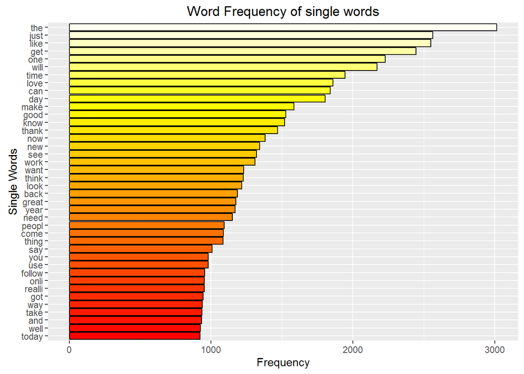

```r
# plot 30 most frequent words
s <- ggplot(word_Freq, aes(reorder(rn, word_Freq), word_Freq))

s <- s + geom_bar(stat = "identity", fill=heat.colors(40) ,colour="black")
s <- s + coord_flip()
s <- s + ggtitle("Word Frequency of single words")
s <- s + ylab("Frequency")
s <- s + xlab ("Single Words")
s
```

Next step is to create similar plots for biagrams and triagrams.NLP package will be used for this scope

```r
Bigram <-
  function(x)
    unlist(lapply(ngrams(words(x), 2), paste, collapse = " "), use.names = FALSE)

Trigram <-
  function(x)
    unlist(lapply(ngrams(words(x), 3), paste, collapse = " "), use.names = FALSE)
```

Tokenizer function has been applied to transform data and present the relevant top 40 plots for the sequence of 2 adjacent words

```r
TDM_Corpus.bigrams <- TermDocumentMatrix(Corpus, control = list(tokenize = Bigram))
TDM_Corpus.bigrams.common <- removeSparseTerms(TDM_Corpus.bigrams, .999)
dim(TDM_Corpus.bigrams.common)
frequency.bigrams <- rowSums(as.matrix((TDM_Corpus.bigrams.common)))
ord <- order(frequency.bigrams)
frequency.bigrams[head(ord)]
frequency.bigrams[tail(ord, n = 40)]
word_Freq_Bigram <- frequency.bigrams[tail(ord, n = 40)]

word_Freq_Bigram  <- as.data.frame(word_Freq_Bigram )
word_Freq_Bigram <- setDT(word_Freq_Bigram, keep.rownames = TRUE)
word_Freq_Bigram <- word_Freq_Bigram[order(word_Freq_Bigram, decreasing = TRUE),]
```

Top 40 words are presented through a sequence of 2 adjacent words

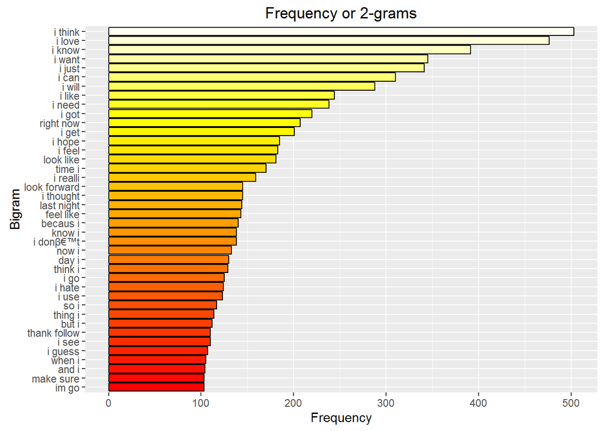

```r
b <- ggplot(word_Freq_Bigram, aes(reorder(rn, word_Freq_Bigram), word_Freq_Bigram))

b <- b + geom_bar(stat = "identity", fill=heat.colors(40) ,colour="black")
b <- b + coord_flip()
b <- b + ggtitle("Frequency or 2-grams")
b <- b + ylab("Frequency")
b <- b + xlab ("Bigram")
b
```

Tokenizer function has been applied to transform data and present the relevant top 40 plots for the sequence of 3 adjacent words

```r
TDM_Corpus.trigrams <- TermDocumentMatrix(Corpus, control = list(tokenize = Trigram))
TDM_Corpus.trigrams.common <- removeSparseTerms(TDM_Corpus.trigrams, .999)
dim(TDM_Corpus.trigrams.common)
frequency.trigrams <- rowSums(as.matrix((TDM_Corpus.trigrams.common)))
ord <- order(frequency.trigrams)
frequency.trigrams[head(ord)]
frequency.trigrams[tail(ord, n = 40)]
word_Freq_Trigram <- frequency.trigrams[tail(ord, n = 40)]

word_Freq_Trigram  <- as.data.frame(word_Freq_Trigram )
word_Freq_Trigram <- setDT(word_Freq_Trigram, keep.rownames = TRUE)
word_Freq_trigram <- word_Freq_Trigram[order(word_Freq_Trigram, decreasing = TRUE),]
```

Top 40 words are presented through a sequence of 3 adjacent words

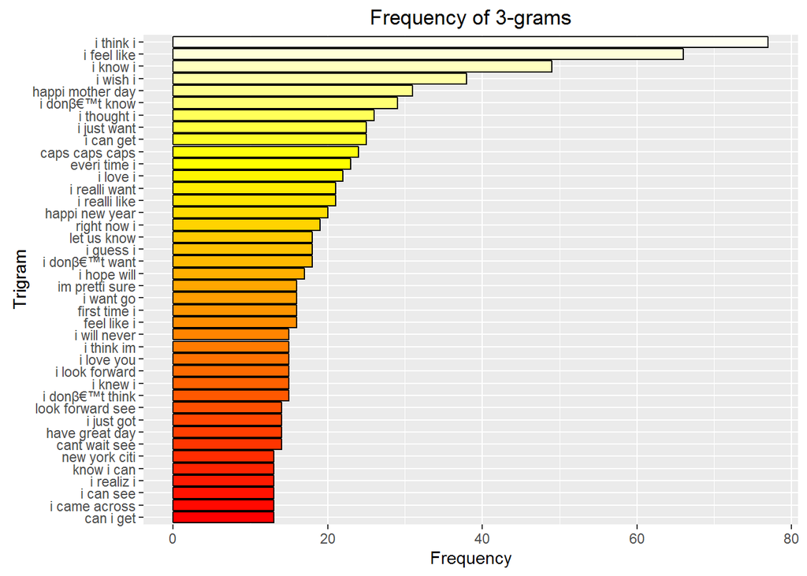

```r
t <- ggplot(word_Freq_Trigram, aes(reorder(rn, word_Freq_Trigram), word_Freq_Trigram))

t <- t + geom_bar(stat = "identity", fill=heat.colors(40) ,colour="black")
t <- t + coord_flip()
t <- t + ggtitle("Frequency of 3-grams")
t <- t + ylab("Frequency")
t <- t + xlab ("Trigram")
t
```

# Next Steps

This analysis of the most commongly used words and word pairs give us a sense of the frequency of these words by combining these datasets. We could present frequencies of each of those datasets by following similar steps but it wouldn’t provide us any additional insight. Next steps include the implementation of the prediction model along with the ShinY App itself.

# Prediction Model

Prediction Model should be based on this Coprus hence every word provided (as user types), will be compared with this Coprus and a relevant word will be suggested based on the frequency.